# Weight Loss Data frame

# load libraries

```r
#install.packages("olsrr")
#install.packages("descriptr")
#install.packages("psych")
#install.packages("modelr")
#install.packages("tidyverse")
#install.packages("mosaic")
library("olsrr")
library("descriptr")
#library("psych") #<- actually don't need this package for this session
library("modelr")
library("tidyverse")
library("mosaic")
```

# Import data

```r
wtloss <- read_csv("wtloss.csv")
```

```r
wtloss <- select(wtloss, lbslost, caldef)
wtloss
```

| lbslost | caldef |
| --- | --- |
| 4.7100912 | 9.0740314 |
| 2.7846008 | 9.3019157 |
| 4.9333754 | 17.5788634 |
| 6.2482989 | 9.1908572 |
| 1.7348242 | 8.7029005 |
| 4.4411348 | 15.6525264 |
| 2.0663362 | 5.8286340 |
| 0.2984090 | 6.1675425 |
| 0.9464819 | 9.3941337 |
| 3.7392596 | 12.6976745 |

[output cut: 90 more lines]

# Research Question

**Is Caloric Defecit a reasonable predictor of weight loss?**

# Data & Description of variables

A research team is interested in assessing the relationship between caloric deficit and pounds lost over the course of a 1 month weight loss program designed for men age 40 to 50 in CO. 100 obese men were randomly selected to participate. She measured the following variables:

1. lbslost = pounds lost after one program **REMEMBER** a negative # means that there were pounds GAINED by the participant
2. caldeff = caloric deficit over the course of the program (expressed in 1000 calories). A caloric deficit is a state in which you are burning more calories than you eat.
3. selfeff = self efficacy for weight loss at the start of the program DATASET: wtloss.csv

# Get descriptive Statistics

## Numeric summaries of key variables

### Pounds Lost

```r
summary_stats(wtloss$lbslost)
```

```
                        Univariate Analysis

 N                      100.00      Variance                 4.40
 Missing                  0.00      Std Deviation            2.10
 Mean                     3.06      Range                   10.76
 Median                   3.14      Interquartile Range      3.07
 Mode                    -3.19      Uncorrected SS        1374.33
 Trimmed Mean             3.11      Corrected SS           435.83
 Skewness                -0.33      Coeff Variation         68.49
 Kurtosis                -0.22      Std Error Mean           0.21

                              Quantiles

              Quantile                            Value

             Max                                   7.56
             99%                                   7.30
             95%                                   5.58
             90%                                   6.04
             Q3                                    4.70
             Median                                3.14
             Q1                                    1.62
             10%                                   0.30
             5%                                   -0.07
             1%                                   -1.58
             Min                                  -3.19

                            Extreme Values

                Low                                High

    Obs                   Value            Obs                   Value
     93                 -3.1904565          13                 7.5647785
     66                 -1.5595839          24                 7.2924021
     80                 -1.0083407          22                 6.3813312
     71                 -0.7865195          43                 6.3052286
     41                  -0.75858           4                  6.2482989
```

```r
summary_stats(wtloss$caldef)
```

```
                        Univariate Analysis

 N                      100.00      Variance                26.40
 Missing                  0.00      Std Deviation            5.14
 Mean                    10.80      Range                   25.84
 Median                  10.69      Interquartile Range      6.64
 Mode                    -2.27      Uncorrected SS       14286.03
 Trimmed Mean            10.82      Corrected SS          2613.56
 Skewness                -0.08      Coeff Variation         47.56
 Kurtosis                 0.13      Std Error Mean           0.51

                              Quantiles

              Quantile                            Value

             Max                                  23.57
             99%                                  22.89
             95%                                  17.14
             90%                                  17.98
             Q3                                   13.89
             Median                               10.69
             Q1                                    7.25
             10%                                   4.86
             5%                                    1.20
             1%                                   -1.31
             Min                                  -2.27

                            Extreme Values

                Low                                High

    Obs                   Value            Obs                   Value
     93                 -2.2662885          13                 23.5721318
     19                 -1.3050408          28                 22.8848039
     80                 0.2212014           22                 21.8911868
     91                 0.7981715           43                 20.6310391
     76                 1.0252767          100                 19.3067112
```

## Histograms of pounds lost and caloric defecit

### Pounds lost

Relatively normal

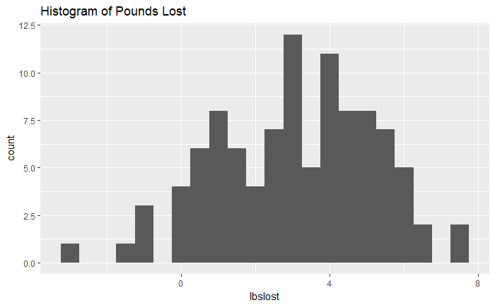

```r
ggplot(wtloss, aes(x = lbslost)) +
geom_histogram(binwidth = .5) +
labs(title = "Histogram of Pounds Lost")
```

### Caloric defecit

Relatively normal

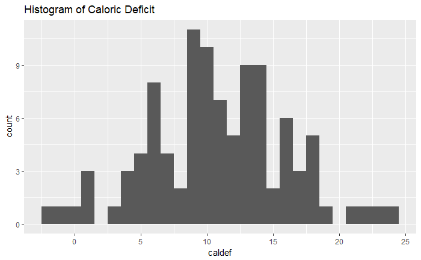

```r
ggplot(wtloss, aes(x = caldef)) +
geom_histogram(binwidth = 1) +
labs(title = "Histogram of Caloric Deficit")
```

## Scatterplot of caloric defecit and pounds lost

Postive, seems to have a trend, could fit a linear line to it.

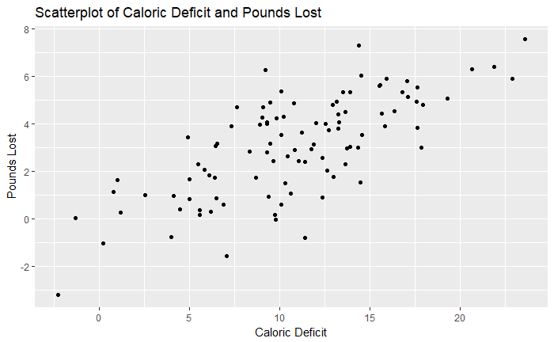

```r
ggplot(wtloss, aes(x = caldef, y = lbslost)) +
geom_point() +
labs(title = "Scatterplot of Caloric Deficit and Pounds Lost", x = "Caloric Deficit", y = "Pounds Lost")
```

## Description of scatterplot

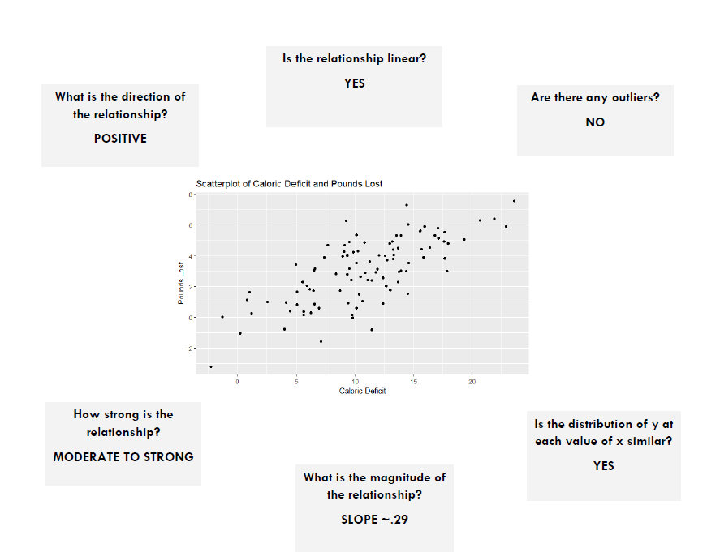

# Fit linear regression model

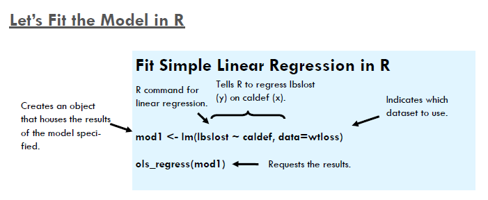

```r
mod1 <- lm(lbslost ~ caldef, data=wtloss)
ols_regress(mod1)
```

```
                        Model Summary
--------------------------------------------------------------
R                       0.722       RMSE                1.460
R-Squared               0.521       Coef. Var          47.647
Adj. R-Squared          0.516       MSE                 2.131
Pred R-Squared          0.504       MAE                 1.149
--------------------------------------------------------------
 RMSE: Root Mean Square Error
 MSE: Mean Square Error
 MAE: Mean Absolute Error

                               ANOVA
--------------------------------------------------------------------
               Sum of
              Squares        DF    Mean Square       F         Sig.
--------------------------------------------------------------------
Regression    227.034         1        227.034    106.558    0.0000
Residual      208.801        98          2.131
Total         435.835        99
--------------------------------------------------------------------

                                  Parameter Estimates
---------------------------------------------------------------------------------------
      model      Beta    Std. Error    Std. Beta      t        Sig      lower    upper
---------------------------------------------------------------------------------------
(Intercept)    -0.121         0.341                 -0.354    0.724    -0.798    0.556
     caldef     0.295         0.029        0.722    10.323    0.000     0.238    0.351
---------------------------------------------------------------------------------------
```

## What to look for in your lm output:

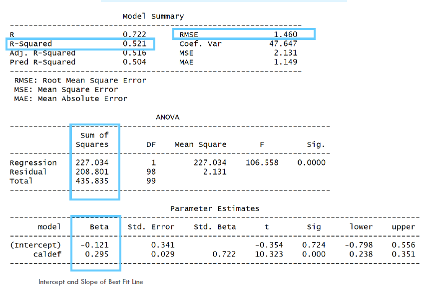

## Scatterplot of caloric deficit and pounds lost, add best fir line

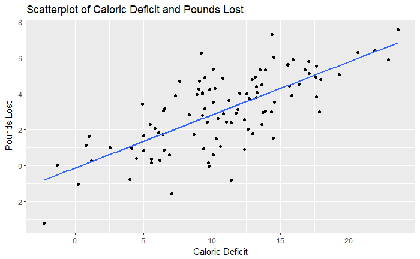

```r
ggplot(wtloss, aes(x = caldef, y = lbslost)) +
geom_point() +
geom_smooth(method = "lm", se = FALSE) +
labs(title = "Scatterplot of Caloric Deficit and Pounds Lost", x = "Caloric Deficit", y = "Pounds Lost")
```

## Get predicted values and residuals

```r
#This code is adding your predicted (y-hat) values and the residuals (error) to our dataset... feel free not to add it to your original dataset if you want too.
wtloss <- wtloss %>%
add_predictions(mod1) %>%
add_residuals(mod1)
```

## Use data_grid to get predictions for new y

```r
predgrid <- data_grid(wtloss, caldef = c(-2, 0, 10.8, 20)) %>%
add_predictions(mod1)
#10.8 = the mean value of pounds lost FYI
```

## Recenter caldef at the mean

Notice how everything inour results are the same EXCEPT for our intercept. It may be more meaningful.

This becomes critically important when we begin to look at interactions/moderators (get used to this neil, they mean the same thing!)

```r
wtloss <- wtloss %>%
mutate(caldef_m = caldef - mean(caldef)) #taking the cal def score of each invidual  and subtracting it from its mean
mod2 <- lm(lbslost ~ caldef_m, data = wtloss) #This model incorporates our centered mean
ols_regress(mod2)
```

```
                        Model Summary
--------------------------------------------------------------
R                       0.722       RMSE                1.460
R-Squared               0.521       Coef. Var          47.647
Adj. R-Squared          0.516       MSE                 2.131
Pred R-Squared          0.504       MAE                 1.149
--------------------------------------------------------------
 RMSE: Root Mean Square Error
 MSE: Mean Square Error
 MAE: Mean Absolute Error

                               ANOVA
--------------------------------------------------------------------
               Sum of
              Squares        DF    Mean Square       F         Sig.
--------------------------------------------------------------------
Regression    227.034         1        227.034    106.558    0.0000
Residual      208.801        98          2.131
Total         435.835        99
--------------------------------------------------------------------

                                 Parameter Estimates
-------------------------------------------------------------------------------------
      model     Beta    Std. Error    Std. Beta      t        Sig     lower    upper
-------------------------------------------------------------------------------------
(Intercept)    3.063         0.146                 20.988    0.000    2.774    3.353
   caldef_m    0.295         0.029        0.722    10.323    0.000    0.238    0.351
-------------------------------------------------------------------------------------
```

## finding our standard errors and t & p-values

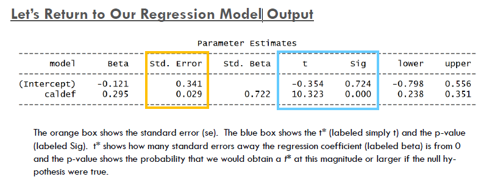

## How to calculate your standaed errors (for bo and b1)

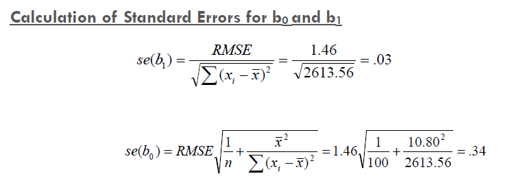

## How to calculate the confidence intervals

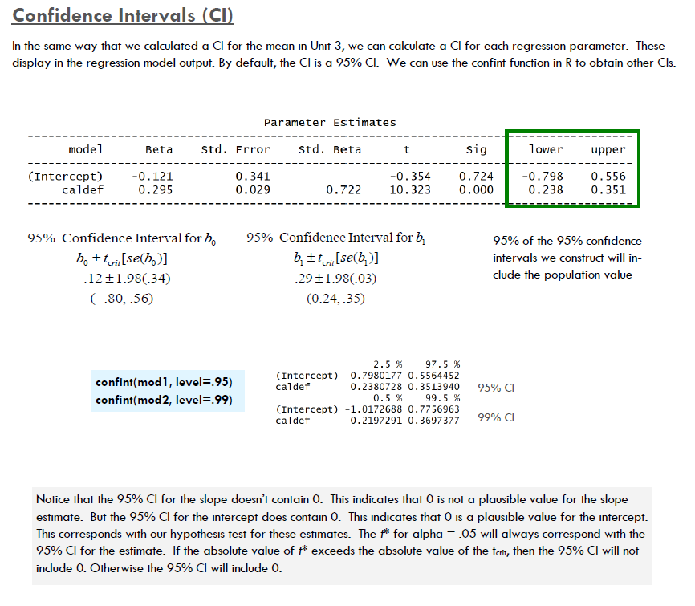

```r
#asking for the 99% confidence interval of model 1
confint(mod1, level=.99)
```

```
                 0.5 %    99.5 %
(Intercept) -1.0172688 0.7756963
caldef       0.2197291 0.3697377
```

```r
#asking for the 95% confidence interval of model 1. Note, that the 95% confidence interval is default.
confint(mod1)
```

```
                 2.5 %    97.5 %
(Intercept) -0.7980177 0.5564452
caldef       0.2380728 0.3513940
```

```r
predgrid <- data_grid(wtloss, caldef = c(-2, 0, 7, 10.8, 20))
predict(mod1, predgrid, interval = "confidence", level = .95)
```

```
         fit        lwr        upr
1 -0.7102531 -1.4914220 0.07091589
2 -0.1207863 -0.7980177 0.55644521
3  1.9423476  1.5812927 2.30340242
4  3.0623345  2.7726686 3.35200042
5  5.7738818  5.1777232 6.37004042
```

```r
predict(mod1, predgrid, interval = "prediction", level = .95)
```

```
         fit        lwr      upr
1 -0.7102531 -3.7103954 2.289889
2 -0.1207863 -3.0955588 2.853986
3  1.9423476 -0.9767258 4.861421
4  3.0623345  0.1512290 5.973440
5  5.7738818  2.8165124 8.731251
```

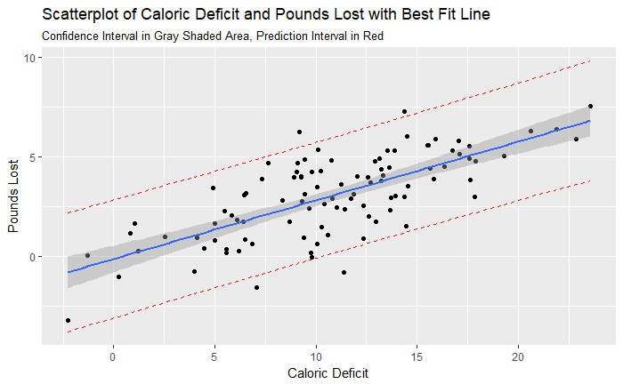

```r
temp_var <- predict(mod1, wtloss, interval="prediction") #<- this is created our "CI's"
wtloss_new <- cbind(temp_var, wtloss)
ggplot(wtloss_new, aes(x = caldef, y = lbslost)) +
  geom_point() +
  geom_smooth(method = "lm", se = TRUE) +
  geom_line(aes(y=lwr), color = "red", linetype = "dashed") +  #putting in the lower predicted CI
  geom_line(aes(y=upr), color = "red", linetype = "dashed") +   # putting in the higher predicted CI's (lwr and upr come from the "temp_var" dataset)
  labs(title = "Scatterplot of Caloric Deficit and Pounds Lost with Best Fit Line",
  subtitle = "Confidence Interval in Gray Shaded Area, Prediction Interval in Red",
  x = "Caloric Deficit", y = "Pounds Lost")
```

# Critical F

```r
qf(.95, df1=1, df2=98)
```

```
[1] 3.938111
```

```r
cor.test(wtloss$caldef, wtloss$lbslost)
```

```
    Pearson's product-moment correlation

data:  x and y
t = 10.323, df = 98, p-value < 2.2e-16
alternative hypothesis: true correlation is not equal to 0
95 percent confidence interval:
 0.6121017 0.8041627
sample estimates:
      cor
0.7217459
```

## Get correlation from correlation between y-hat and y.

```r
cor.test(wtloss$pred, wtloss$lbslost)
```

```
    Pearson's product-moment correlation

data:  x and y
t = 10.323, df = 98, p-value < 2.2e-16
alternative hypothesis: true correlation is not equal to 0
95 percent confidence interval:
 0.6121017 0.8041627
sample estimates:
      cor
0.7217459
```

## Get correlation through a SLR on z-scores

```r
wtloss <- wtloss %>%
  mutate(caldef.z = zscore(caldef), lbslost.z = zscore(lbslost))
mod1_z <- lm(lbslost.z ~ caldef.z, data=wtloss)
ols_regress(mod1_z)
```

```
                           Model Summary
--------------------------------------------------------------------
R                       0.722       RMSE                      0.696
R-Squared               0.521       Coef. Var          1.392263e+18
Adj. R-Squared          0.516       MSE                       0.484
Pred R-Squared          0.504       MAE                       0.548
--------------------------------------------------------------------
 RMSE: Root Mean Square Error
 MSE: Mean Square Error
 MAE: Mean Absolute Error

                               ANOVA
--------------------------------------------------------------------
               Sum of
              Squares        DF    Mean Square       F         Sig.
--------------------------------------------------------------------
Regression     51.571         1         51.571    106.558    0.0000
Residual       47.429        98          0.484
Total          99.000        99
--------------------------------------------------------------------

                                 Parameter Estimates
--------------------------------------------------------------------------------------
      model     Beta    Std. Error    Std. Beta      t        Sig      lower    upper
--------------------------------------------------------------------------------------
(Intercept)    0.000         0.070                  0.000    1.000    -0.138    0.138
   caldef.z    0.722         0.070        0.722    10.323    0.000     0.583    0.860
--------------------------------------------------------------------------------------
```

```r
r <- (sd(wtloss$caldef)/sd(wtloss$lbslost))*0.295
```